# The Evidence of My Alien Interaction

> “The true method of advancing knowledge is to bring together things that seem remote and to show their connection” Isaac Newton

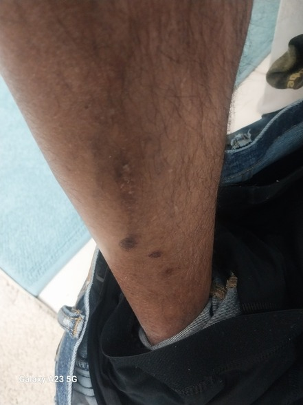

**As promised here it is:**

This may be a bit longer form although I’m going to try to be as brief as possible. First, I have previously written a book, then a screenplay called [Theories](https://www.youtube.com/watch?v=jblj5GRGVLA) about the government’s and our new beginnings in this path of alien and technological interaction starting with the Trinity A-bomb. The first 20 pages are [free to read](https://www.scriptrevolution.com/scripts/theories) and download. It takes us through first contact. I’m mentioning this because when researching and especially while writing Theories quite a few strange events were happening. And not the first time in my life. I also had a near death experience at the age of 11 that opened me up to what this universe is, the very essence of life and death, our purpose here, and the importance of the greatest power that ever was or will be - unconditional love. Yes, I was vividly in that light everyone talks about. That’s another story too long for this document. The connection is that once the door is opened and the light switch goes on, one could only turn it off at one’s own foolish peril. I’m also stating this to say that it seems that many who have seen UFOs/UAPs or had contact experiences also have had previous conscience shifting experiences that exposes them to other realms that co-exist with this one. In fact, I have been able to ‘travel’ beyond my physical body for many, many years. Our realm, this universe that we know is actually very dense and crowded with other realms and beings. That’s definitely too much to unpack here. I can now do this traveling at will, simply by closing my eyes and not giving over to fear. Fear kills the experience instantly. Fear is the great destroyer. Fear is so powerful that apparently it is the opposite of love - a spot typically reserved for hate. I’ve since learned that not all the beings or ‘energies’ out there are of love. I’ve learned how to be with the loving ones by simply asking at the outset. The few others, not fully in the vein of love actually seem to be disturbed by my presence, sometimes aggressively. I’ve experienced beings and places, some not of this earth. That is for another posting. I’m trying to stay as brief as possible here although there is much to say.

**So what happened to me this year? 1. BEAUTIFUL CRAFT SIGHTING**

*Ardmore, Pennsylvania - December 6, 2023*

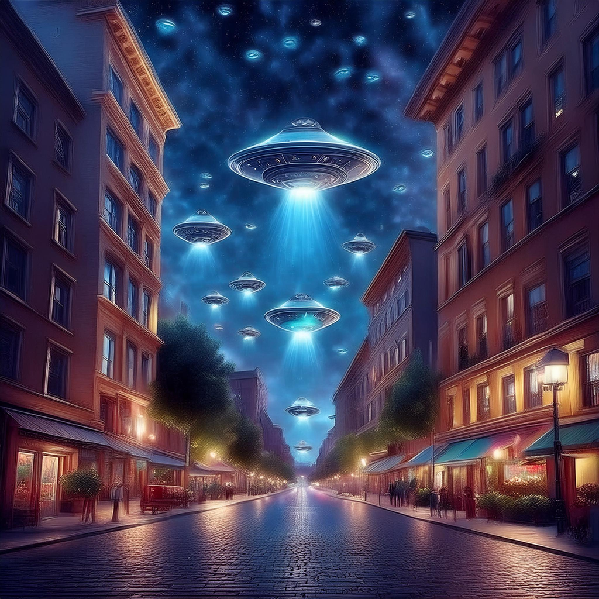

On the night of December 6, 2023, I was preparing to go to bed. The location is Ardmore, Pennsylvania. I have been in a perpetual state of quitting smoking after starting again a year or so earlier. It was 9:45 pm and I went out the back door as normal to smoke and look at the night sky. I’m someone who loves the night sky and nature in general. I was facing north. There was a bright moon illuminating low hung, slightly billowy clouds slowly passing overhead. The angle of the moonlight made for some pretty viewing. Most of the sky was clear, then out of nowhere, coming from the south-east in the corner of my eye appeared a bluish ball of light. Kind of shocked, I turned in that direction. Following the ball of light was another and then many more as if following the leader. They were moving due north, traversing air space quickly, but not like a streak of a meteor fast. For a few seconds they all still looked like bluish glowing orbs flying just below the cloud canopy. My eyes followed them northward when the leader orb titled or banked and I realized that they were not orbs but crafts. I could clearly see the leader as a disk similar to a solid Frisby with a smaller Frisby sitting on the top. All the following now looked exactly the same. More were following. There were about 12 to 15 of them. They were flying in a pattern that looked a wide, stretched out M-shape across the sky. Where the leader tilted or banked, they too did the same. All had the same bluish glow surrounding a silver-ish body in the same double-Frisby shape. The moon backlight was perfect, cinematic. I can tell you that they were stunningly beautiful, no sound, no exhaust trails, just smoothly coursing below the night cloud canopy heading due north until out of sight. The entire incident was about 20 seconds.

I was amazed. So beautiful it took my breath away. I stood there in the cold for about another minute scanning all around as far as I could see, and that was it. I did not have my phone in my pocket and glad I didn’t. I just had my own eyes and realized I had just seen a group of UFOs. It seemed like a privilege. To not forget anything, once inside I grabbed a notebook and drew it on paper noting the time, their flight direction, the characteristics of the clouds, the moonlight, everything including trying to remember how many there were.

As had happened many times before particularly while researching and writing Theories, about 10 minutes post an anomaly or sighting by me, the noise of a helicopter approached. I dashed out the back again to check, and a black hawk military chopper was heading in the opposite direction from north to south east. I assume that they get a signature or radar event that’s not theirs or unidentified and then fly along the vector to check it out. This happened a lot while writing Theories. I did not report this sighting to MUFON or anyone else because I didn’t want any unknown knocks at the door.

A couple of weeks earlier I had cut myself in the kitchen foolishly trying to cut a squash in half. It went to the bone and I still had stitches but was too busy to get them removed. Saturday December 9, 2023, three days after the sighting, I went to the hospital to get the stitches out. It was pretty much routine although I still don’t have full feeling in that finger. On the way out, as soon as the double glass door slid open, I walked through and noticed a striking blond woman closer to my age sitting in a corner chair who looked like she was waiting for someone. She immediately perked up and smiled directly at me. It might not sound like much, but she said to me a complete stranger, “Take care of yourself”. I said “Yes, and you too”. I instantly felt like I had known this woman my whole life. I did not. I realized that she was slim and on the tall side. I couldn’t get over the familiarity but didn’t want to creep her out by staring. So, I went on my way. Later I remembered a series of images I had from years before when researching Theories. I found it. She’s below. The man on the right is supposedly [Valiant Thor](https://mru.ink/valiant-thor-stranger-in-the-pentagon/). I hear the chuckling but I don’t care. The other man and the lady were with him in this image. They are alleged to be his siblings. Is it her? I can’t say for sure but I can say that she definitely has a doppelganger in 2024 who was at Bryn Mawr Hospital in Pennsylvania on the afternoon of December 9, 2023. I now also think that she was the same woman I remember who was around after my emergency appendectomy at 8 years old at the same hospital. I was close to the edit. She was a very comforting and loving woman as of course my mother was but she had to work during the day. I remember them meeting and talking one day. This is the same hospital I was born in where I almost didn’t make it here. I wouldn’t breathe. Moving on…

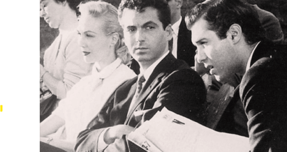

3. **EVENT IN WASHINGTON DC - February 21, 2024**

I am a design/builder/project dev among the many things I do and have done. A business partner and I lost a house deal a few weeks earlier. It was the house I was living in where I had the sighting. I headed down to DC for a while to figure out my next moves. I have family there but still had active client bids in the Philadelphia area and needed to figure out how to get them going and done. All that was taking too long and as no stranger to DC, it began to grow on me. I was staying near Rock Creek Park and the National Zoo having taken many hikes through the area. January turned to February and I still hadn’t figured it all out, where to be, how to get it done. One day I was looking for a ticket to Philly to close a remodel deal and found a few ticket prices but I knew from experience to wait and try to get a cheap Amtrak seat. If not, there’s always the next day. It was getting near dark when I decided to take a shorter walk down though Rock Creek Park. A few people were still out. I was wearing a borrowed black winter jacket with a hood, my Marmot cap, jeans, hiking boots and gloves. I went along a known course to the top of a hill and sat down on a log. I did not check the phone for ticket prices, I was just enjoying the woods quietly turning to night when I thought I should start heading back. There was no one nearby although I could still see a couple of bike lights on the path below. I had a Timex Expedition watch on and I checked the time. It glowed 6:30 pm. That’s when it all began.

**I LOST 13 HOURS OF TIME**

I remember sitting on a log looking over the creek and bike paths below, and across the road where cars were traveling. A steep hill lay beyond the road back towards the city. Adam’s Morgan I think is the neighborhood. If you’ve ever been there, the hill down to the zoo is pretty steep. **It was then I saw what appeared to be an odd red glow at the top of the opposite hill. The glow was very unusual as there was no center point of light. Just a red glowing, transparent shimmer about 200 feet wide**. It was not static. It was slowly coming over and down the hill in my direction. I had no idea what it was. Then underneath the red glow a curtain of bright white light dropped underneath. I’d never seen light like this. That light had many of the same qualities. No central light, just imagine a curved curtain of white light about 200 feet wide. All red above, all white below, was still coming in my direction when I first thought, “I’m hallucinating”. I do remember thinking that I should get up and leave but the lights were right in the only path I knew to get back up the hill to the city streets. I had no flashlight. Instead I went deeper in along the trail. Time and events are bit hazy and sketchy to convey accurately, but at one point I thought I saw a big black bear on the trail. I froze like a rabbit and tried to observe it. The night was a dim one and I couldn’t see too well. It wasn’t like something made me freeze, I could certainly move or run but I had concluded that the safest thing to do was stay absolutely still. I was aware enough to think, “There probably aren’t any bears around here and if there are, they should be hibernating”. I truly am not sure what it was. I only know that something large was definitely there near the side of the path. It had an obvious presence. Malevolent or benevolent, I had no clue which. I had my phone and never once thought to call 911. I do remember thinking to not walk to or attempt to travel through the city streets if I’m hallucinating. That might end up worse. I’m very much an outdoors guy and thought it best to stay in the woods no matter what. I next remember quietly walking through the woods and sitting down again. This time the white curtain of light was huge and just behind yet also around me, enclosing. I thought that , “Oh, I’ve stumbled upon a theater in the park or someone is shooting a movie.” Whatever was going on, rationality kicked in again as I knew it was the third week of February and that there was certainly no summer theater in the park.

**That’s the last thing I remember of that night.**

I was woken up in a field at the base of a large tree by a flock of wild turkeys passing by. Smaller hens first and by the time I realized what they were, a huge tom turkey was in the rear position. It was so close I could have reached out with my left arm and grabbed its neck. They made a small racket running and fluttering away. It was now daylight. I looked at my watch. It was 7:30 am. I tried to get up and immediately fell back down. It was like I had run a couple of marathons that night. My body was totally useless and not responding as it should have. It was incredibly disorienting like backing up with a travel trailer for the first time. Using the tree for support I finally was able to stand, just barely though. I was thoroughly wobbly and my body could barely control one single physical command. Worse, I had to take a leak. I remember leaning my shoulder on the tree for support to relieve myself without messing up my jeans. I tried walking and fell down repeatedly and then I heard voices. I thought it was another hallucination. Strangely, it was the sound of two females in English that I could understand that sounded as if they were standing right next to me, like preternatural hearing but then I realized it was coming from a road or trail nearby. I crawled in that direction.

The road was a good 100 yards away but I made it and could finally, yet barely stand up. In seconds it seems, a gentleman hiker came by. He asked if I was lost. I told him that I knew exactly where I was although I didn’t know my ass from a hole in the ground. He didn’t buy it and thank God he didn’t. He asked me to walk with him to the ranger station. Once at the ranger station I sort of collapsed. He and the lady ranger were trying to figure out what had happened to me and they eventually called the paramedics. I still had my phone. I still had my wallet. I still remembered how to unlock it. They asked a bunch of questions one of which included how did you get here? I told them that I met the gentleman on the road. They said, what road? I said the road out there, double lines, the paved road. They all said that the road where I was found was a dirt road but I was adamantly sure otherwise. That’s when I truly realized without a doubt that something was really, really wrong with me. The EMT guys did try to call some DC or same last name numbers. They loaded me up and took me to George Washington Hospital. I fell asleep and looked out the window. I swore I was at Bryn Mawr Hospital in Pennsylvania.

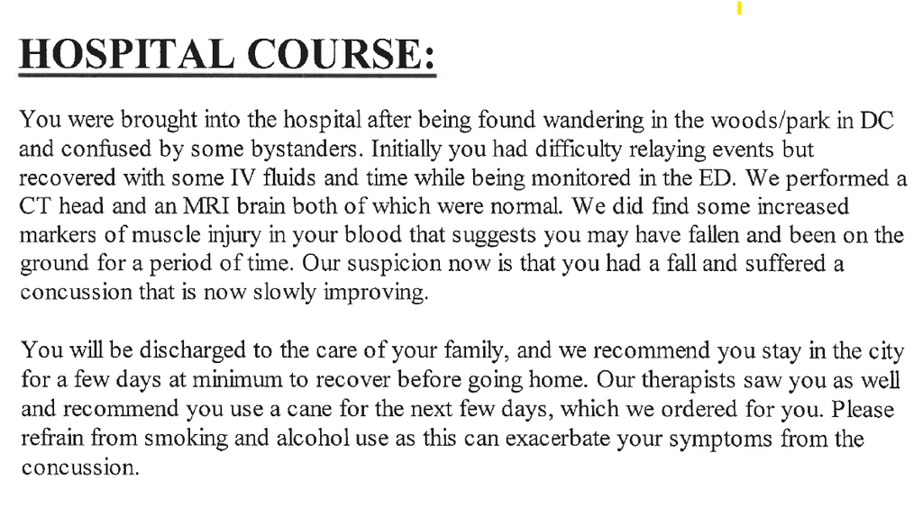

At GW Hospital my recovery began. I was also told to my astonishment that I was in Washington DC not Pennsylvania. I received many IVs and test after test after test, MRIs, CAT scans, etc., as shown in the images.

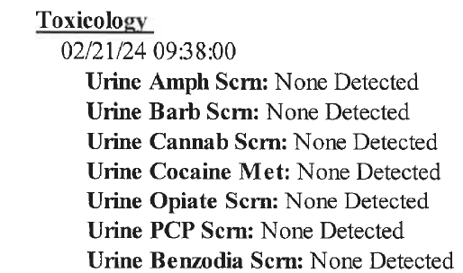

I was still hallucinating at times and even imagined that my sons were there talking in the back of the room. They weren’t. By the time they reached my sister and she came to the hospital, the IVs were helping but I soon realized that I could not answer her questions coherently. I was also still hallucinating. I was seeing weird looking translucent purple silverfish in the crevices of my bed sheets. A large nurse firmly stated that there are no bugs in the sheets! I let it go. That eventually went away.

But when I finally got to talk to the doctor, he asked where I was when I got picked up. I told him a ranger station, where I don’t know. **He seemed a bit concerned that it was not mentioned in the EMT’s report which is highly unusual - it’s always in the report, he said**. He revisited the question a few times as I recovered. I didn’t know. They kept me for a day, but to this day there is no record of where I was picked up or even which EMT unit brought me in.

The doctor concluded that I had fallen and had a concussion and that a blood test showed that I was laying on the ground for some time in the cold. That kind of made sense to me but the only falling I remember occurred on the morning I woke up in the field and definitely not at the outset of the previous night. **And for all that being in the woods all night and supposedly having a concussion and being on the ground, my clothes were absolutely spotless showing not one dot of dirt or debris and no blood. Perfectly clean and not one single blood spot even on the inside of my jeans.** The pictures made of my legs were taken by me when I got out the next day. I showed them the marks at the hospital and no one could make sense of them. It looks like a healed burn wound, and I was told that by them, but to be healed in one day is impossible under normal circumstances.

**KNEE MARKS**

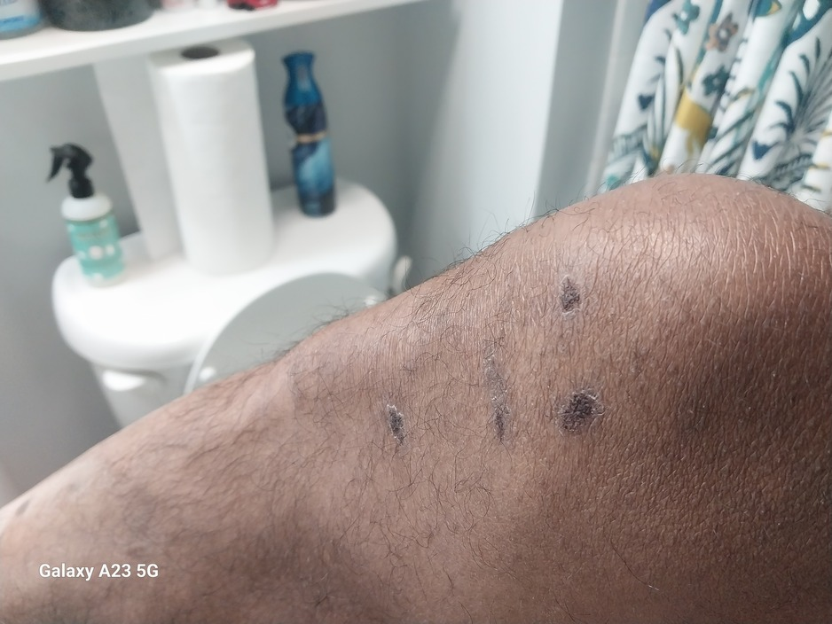

The three knee marks are in the position a doctor would choose if giving a steroid shot into a bad knee. There was no blood. My right knee had started acting up months before and was on the road back to pain which I wanted to avoid from previous experience. I was a hurdler in junior high and high school and it was always that knee. Today my knee feels fine.

**SHIN MARKS**

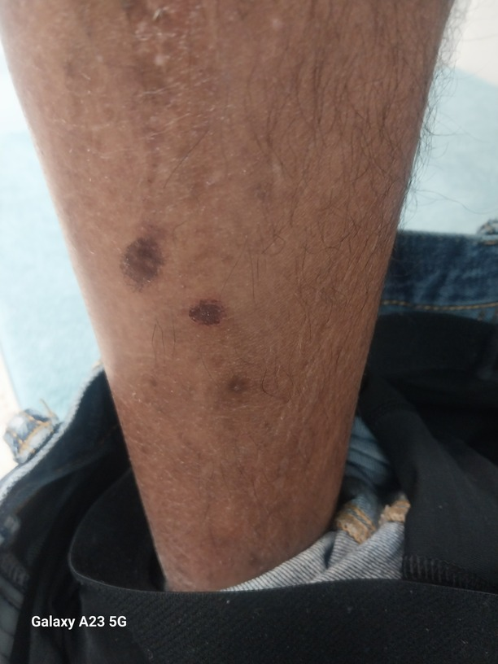

I can’t figure these out. Above the three burn marks is an old shin injury from ten years ago (I’m an active guy). They were all in the same state of apparent burn injury and rapid healing. Again no blood, but these took many months to fully return to their previous state. Did they take bone marrow?

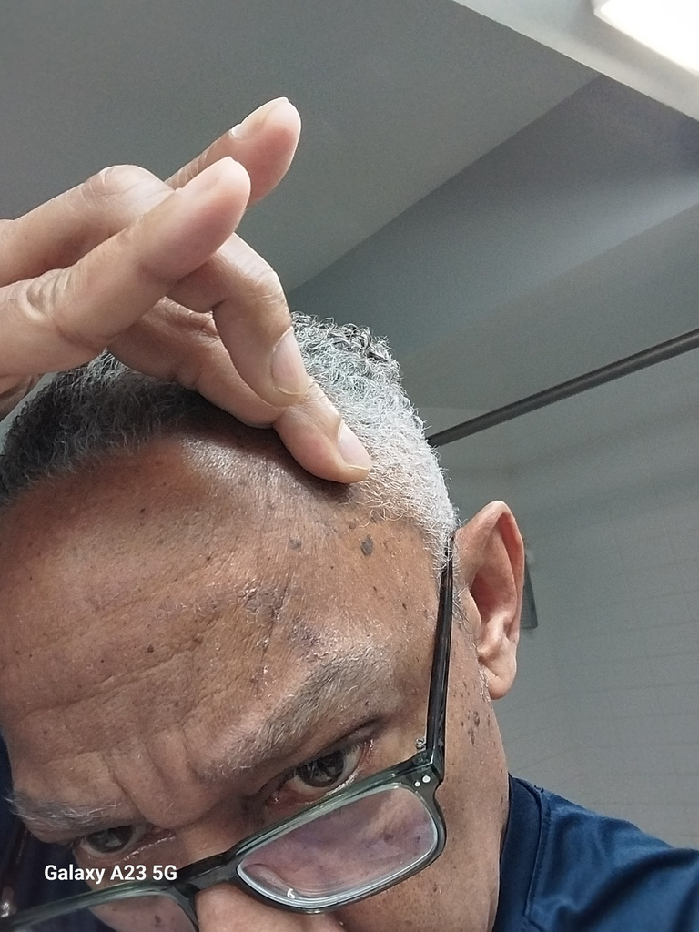

Post covid, especially after the first time (I’ve had it 3 times), I had the worst tinnitus I’ve ever had. Over the last 10 or so years prior it would come and go. Ask anyone who deals with it and they’ll tell you that you need a special routine or mental state to manage it. It had returned hard before this time and was active before this incident. Just one day after the incident, as you can see there were marks like dry skin on my forehead below my fingers. It is less obvious in comparison to the other ‘burn’ marks. Also, you can see something that looks like a healed incision mark that looks like a crease. What you can’t tell from the images is that the **tinnitus is totally gone since this incident and has not returned.** That is invaluable to me. Did they do this? Did she have a hand in this? They does not mean the staff

**IS ALL THIS CONNECTED?** I believe so. What a year and it’s not over yet.

**UPDATE MAY 5, 2025:**

The tinnitus has not returned!

[interactive chart not shown]